# Homework 1

Elijah Hall, eh2794

2018-06-15

```r
library(datasets)
library(class)
library(DT)
library(ggplot2)
library(dplyr)
library(ISLR)
library(scales)
library(corrplot)
library(FNN)
library(data.table)
library(Metrics)
```

```r
#my plotting theme
mytheme <- theme_bw()+
  theme(panel.border = element_blank(),
        axis.line = element_line(color = 'black'),
        plot.background = element_blank(),
        panel.grid.major = element_blank(),
        panel.grid.minor = element_blank())

#2.a
even.or.odd <- function(x, return.idx=FALSE){
  y<-as.logical(x%%2)
  #odd = TRUE and even = FALSE
  idx<-y
  if(return.idx==FALSE){
  y<-as.character(y)
  y[idx]<-"odd"
  y[!idx]<-"even"
  return(y)
  }else{
    return(y)
  }

}


#2.b
my.sum<- function (x, the.type="all"){
  if (the.type=="even"){
    sum(x[!even.or.odd(x,return.idx=T)])
  } else if(the.type=="odd" ){
    sum(x[even.or.odd(x,return.idx=T)])
  } else if(the.type=="all" ){
   sum(x)
  }
}

#3.a
training_row <- function (x, training_row = TRUE, train_prop = .8, seed = 41 ){

  p = train_prop
  idx<- rep(FALSE,nrow(x))
  set.seed(seed)
  samp <- sort(sample(c(1:nrow(x)), round(p * (nrow(x)))), decreasing = FALSE)
  idx[samp]<-TRUE

  if (training_row == FALSE){
    return(!idx)
  } else if(training_row == TRUE  ){
    return(idx)
  }
}
```

```r
set.seed(41)
```

## Question 0: Survey (2 points)

I submitted this online a well, on the google survey link.

I would like to get an idea of your interests in Machine Learning and your background. Please tell me:

Your last degree program (B.A., M.A., E.D., Ph.D., etc) ? **I got my B.A. in Business Finance and Economics, I graduated August 2017.**

Your proficiency with Calculus - Scale 1 (Beginner) -5 (Advanced): **3**

Your proficiency with Linear Algebra - Scale 1 (Beginner) -5 (Advanced): **1**

Your statistical proficiency (Probability, Statistical Distributions) - Scale 1 (Beginner) -5 (Advanced): **3**

Your proficiency with Regression Models (Linear, Logistic, etc.) - Scale 1 (Beginner) -5 (Advanced): **3**

Your proficiency with R programming (Plots, Functions, Rmarkdown), Scale 1 (Beginner) - 5 (Advanced): **3**

## Question 1 (2 points)

We will be using Rstudio in this class to implement the algorithms we learn in class. The goal of this assignment is to get you proficient in the basics of R, such as writing scripts and plotting. If you are having trouble, you can find help by searching the internet (often searching for the specific error message is helpful), reading Data Mining with R by Luis Torgo or R in a Nutshell by Joseph Adler, asking your friends, and coming to office hours. The computing homework needs to be submitted with your name and Uni# with Rmarkdown file and a pdf with the code and explanation.

Install the **R** and **RStudio** programs on your computer. Then, inside of RStudio, use the **install.packages** function to install **RMarkdown**. Then, in the code chunk below, type **version**.

```r
install.packages("rmarkdown")
```

```r
version
```

```
               _
platform       x86_64-w64-mingw32
arch           x86_64
os             mingw32
system         x86_64, mingw32
status
major          3
minor          5.0
year           2018
month          04
day            23
svn rev        74626
language       R
version.string R version 3.5.0 (2018-04-23)
nickname       Joy in Playing
```

## Question 2 (10 points)

### 2a (5 points)

Write a function called **even.or.odd**. Its parameter **x** will be a numeric vector. Return a character vector that says “odd” for odd numbers and “even” for the even numbers. The results should correctly classify every value. To determine if a number is even or odd, you can use the modulus operator **%%** (e.g.: 5%%3 = 2). Note: Try to find a solution that uses vector logic instead of a for loop. In R, this is a good programming practice that will speed up your programs.

Display the results of this function on the vector 1:5.

```r
#create seuqnce to test function
test <- seq(5)
#assign original sequence as names for validation
names(test) <- seq(5)

# even.or.odd() is declared above line 41
# inspect output
even.or.odd(test)
```

```
[1] "odd"  "even" "odd"  "even" "odd"
```

### 2b (5 points)

Write a function **my.sum** that computes the sum of a numeric vector **x**. The user can also specify **the.type** as a character. If **the.type** is “even”, the function will compute the sum of only the even values in **x**. If **the.type** is “odd”, the function will compute the sum of only the odd values in **x**. If **the.type** is “all”, the function will compute the sum of the entire vector **x**. Within the function, you may use the built-in **sum** function. The function should omit missing values (NA) from the sum. This can be done using the **na.rm** argument within the **sum** function.

Display the results of this function for **odd**, **even**, and **all** values of the vector 1:5.

```r
# my.sum() is declared above line 47
#inspect funciton output
my.sum(test,"odd")
```

```
[1] 9
```

```r
my.sum(test,"even")
```

```
[1] 6
```

```r
my.sum(test,"all")
```

```
[1] 15
```

## Question 3 (10 points)

Load package **datasets** and load the **iris** data set. We will try to predict the species of iris from the sepal’s length and width and the petal’s length and width using k−nearest neighbors.

### 3a (5 points)

Divide the data into training and testing sets. To do so, let’s create an assignment vector called **training_row**. Each row of the data set will be assigned to the training set (with **training_row** set to TRUE) with probability 0.8 or to the test set (with **training_row** set to FALSE) with probability 0.2. Use the **sample** function to create the **training_row** vector of TRUE and FALSE values. The vector should be as long as the number of rows in the iris data set.

Then, divide the **iris** data set into separate training and test sets according to the **training_row** assignments.

In order to obtain consistent results, we’ll need to set the seed of R’s pseudo-random number generator. To do so, use **set.seed(41)** in the code chunk labeled **constants** above.

```r
head(iris)
```

```
  Sepal.Length Sepal.Width Petal.Length Petal.Width Species
1          5.1         3.5          1.4         0.2  setosa
2          4.9         3.0          1.4         0.2  setosa
3          4.7         3.2          1.3         0.2  setosa
4          4.6         3.1          1.5         0.2  setosa
5          5.0         3.6          1.4         0.2  setosa
6          5.4         3.9          1.7         0.4  setosa
```

```r
#training_row() is declared above line 58
#inspect training splits
iris_train <- training_row(iris, TRUE, seed=41)
which(iris_train)
```

```
  [1]   2   3   4   5   6   7   8   9  10  12  13  14  15  16  17  18  19
 [18]  20  21  22  23  28  29  31  32  33  34  35  36  37  39  40  43  44
 [35]  45  46  47  48  50  51  52  55  56  57  58  59  60  61  63  64  67
 [52]  68  70  71  73  74  75  76  77  78  81  82  85  86  87  88  89  91
 [69]  92  93  94  95  96  97  98  99 101 102 103 104 107 108 109 110 111
 [86] 112 113 115 116 117 118 119 120 121 122 123 124 125 126 127 128 129
[103] 130 131 132 133 134 135 137 138 140 141 142 143 144 145 147 148 149
[120] 150
```

```r
iris_test <- training_row(iris, FALSE, seed=41)
which(iris_test)
```

```
 [1]   1  11  24  25  26  27  30  38  41  42  49  53  54  62  65  66  69
[18]  72  79  80  83  84  90 100 105 106 114 136 139 146
```

### 3b (5 points)

Use the function **knn** from the package **class** with **k = 2** to classify the data. What proportion of the values are misclassified on the testing set?

**Note**: In order to use *knn*, the **train** and **test** objects must only include the columns that are used to make the classification. The Species will need to be separated into the **cl** vector and removed from the **train** and **test** objects.

```r
#split iris into training
iris_train <- training_row(iris, TRUE,seed = 41, train_prop = .8)
iris_test <- training_row(iris, FALSE, seed = 41, train_prop = .8)

#fit KNN model k = 2
iris_k_2 <- knn(train = iris[iris_train,-5],
                test = iris[iris_test,-5],
                cl = iris[iris_train, 5],
                k = 2 )

#proportion of the values are misclassified on the testing set
mean(iris[iris_test, 5]!=iris_k_2)
```

```
[1] 0.06666667
```

## Question 4 (8 points)

Now perform the **knn** classification for each **k** value from 1 to 50. For each value of **k**, compute the percentage of misclassified values on the testing set. Print out your results as a table showing the values of k and the misclassification rates. You can use the **datatable** function in the **DT** package to display an HTML-friendly table.

**Note 1**: It would help to write a function that performs the knn computation and computes the misclassification rates.

**Note 2**: A for loop is one way to perform the computation on each value of k. As a challenge, look at alternative methods of computing the rates. For instance, using the **data.table** package, you could call this function within the data.table grouping **by** each value of k.

```r
#delare variables
k_s <- seq(50)
p_s <- vector("numeric", length=50)

#fit KNN models for all values of k
for (i in 1:50){
  #fit models
  iris_k_i <- knn(train = iris[iris_train,-5],
                test = iris[iris_test,-5],
                cl = iris[iris_train, 5],
                k = k_s[i] )
  #store misclasifficaiton proportions
  p_s[i] <- mean(iris[iris_test, 5]!=iris_k_i)

}
#create df with all model misclasifficaiton results from different values of k
k_i <- data.frame(k_s,p_s)

#view results
datatable(k_i)
```

|  | k_s | p_s |
| --- | --- | --- |
| 1 | 1 | 0.0333333333333333 |
| 2 | 2 | 0.0666666666666667 |
| 3 | 3 | 0.0333333333333333 |
| 4 | 4 | 0.0333333333333333 |
| 5 | 5 | 0.0333333333333333 |
| 6 | 6 | 0.0333333333333333 |
| 7 | 7 | 0.0333333333333333 |
| 8 | 8 | 0.0666666666666667 |
| 9 | 9 | 0.0333333333333333 |
| 10 | 10 | 0.0333333333333333 |

[output cut: 40 more lines]

## Question 5 (20 points)

Use your answers from Question 4 to display the results.

### 5a (5 points)

Plot the misclassification rates on the testing set versus the value of k. Use the **plot** function. Try different values of the arguments (las, xlim, ylim, xlab, ylab, cex, main) to create a nicer display. Use **type = “both”** to display both the points and a line.

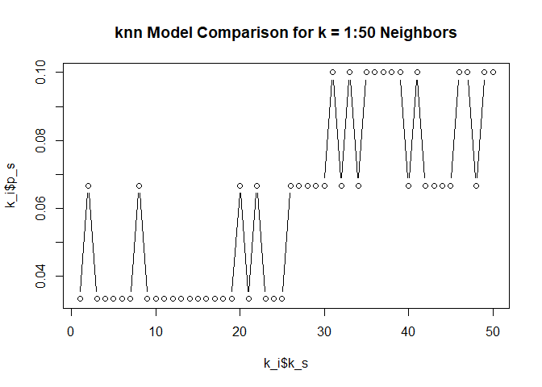

```r
#Plot the misclassification rates
plot(k_i$k_s, k_i$p_s, type = "b",main='knn Model Comparison for k = 1:50 Neighbors')
```

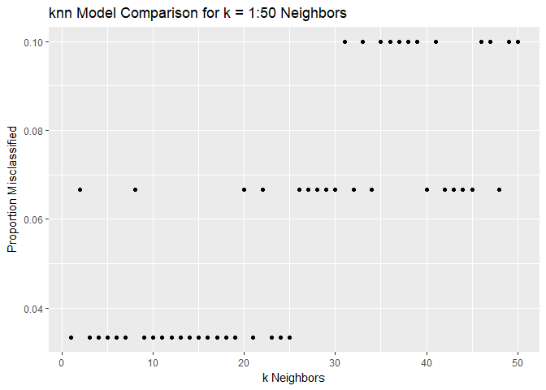

```r
#use ggplot2
ggplot(k_i, aes(x=as.integer(k_s), y= p_s))+
  geom_point() +
    labs(title = 'knn Model Comparison for k = 1:50 Neighbors',
       x = 'k Neighbors', y = 'Proportion Misclassified')
```

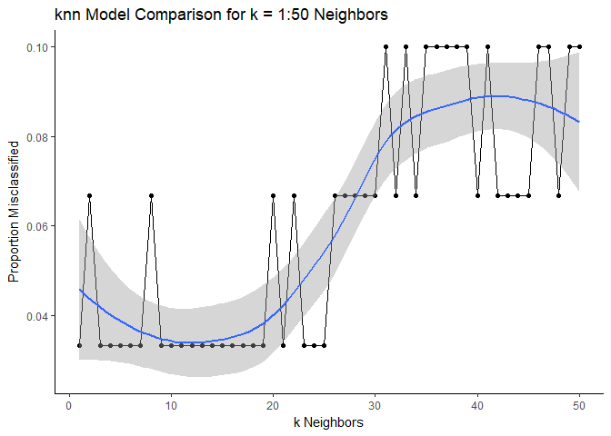

```r
#add line and smoth line
ggplot(k_i, aes(x=as.integer(k_s), y= p_s))+
  mytheme+
  geom_point()+
  geom_line()+
  geom_smooth(method = 'loess')+
  labs(title = 'knn Model Comparison for k = 1:50 Neighbors',
       x = 'k Neighbors', y = 'Proportion Misclassified')
```

### 5b (5 points)

Now create the same plot placing **k** on a *logarithmic* scale. Make sure to change the label of the x axis to distinguish this.

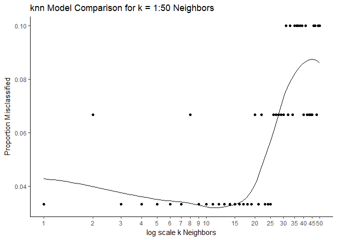

```r
#change x scale to logrithmic
ggplot(k_i, aes(x=as.integer(k_s), y= p_s))+
  mytheme+
  geom_point()+
  geom_smooth(method = 'loess',se = F, color = 'black', lwd = .5) +
  scale_x_log10(breaks = c(1:5,
                           6:10,
                           seq(15, 50, by = 5))) +
  labs(title = 'knn Model Comparison for k = 1:50 Neighbors',
       x = 'log scale k Neighbors', y = 'Proportion Misclassified')
```

### 5c (10 points)

Let’s examine how the results would change if we were to run the knn classifier multiple times. Perform the following steps:

1. Re-perform the previous work 3 more times. Each time, you should create a new training and test set, apply **knn** on each value of **k** from 1 to 50, and compute the misclassification rates on the testing set.
2. Plot the results of the earlier work along with the 3 new iterations on a single plot. Use the **lines** function to add additional lines to the earlier plot from 5a (using the linear scale). Use different colors, line types (lty), and point characters (pch) to distinguish the lines.
3. Use the **legend** command to place a legend in the top left corner (x = “topleft”) of the plot. Use the same colors and point characters to display which line is which. Label the iterations 1 through 4.

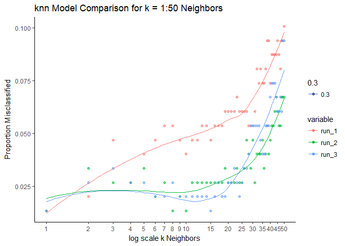

```r
#declare variables
k_s <- seq(50)
#make a list to store all prediction values
p_list <- list()

#run iterations
for(j in 1:3){
  #step one: create training set, change seed
  iris_train <- training_row(iris, TRUE, seed= sample(1:10000,1))

  #step two: apply knn ()
  p_s <- vector("numeric", length=50)

  #run KNN models for k's
  for (i in 1:50){
    iris_k_i <- class::knn(train = iris[iris_train, -5],
                  test = iris[-iris_train, -5],
                  cl = iris[iris_train, 5],
                  k = k_s[i] )
  #store misclassificaiton results for each k
    p_s[i] <- mean(iris[-iris_train, 5]!= iris_k_i )
  }
  #store misclassificaiton results for each sample
  p_list[j] <- list(p_s)
}

#merge results to one data frame
rep_knn_k_i <- data.frame(k_s,p_list)
#change names
names(rep_knn_k_i)<- c("k_s", "run_1", "run_2", "run_3")

#plot results on log scale by runs
ggplot(melt(rep_knn_k_i, id.vars="k_s"), aes(x=as.integer(k_s), y= value, color= variable, alpha =.3))+
  mytheme+
  geom_point()+
  geom_smooth(aes(group = variable,color = variable),method = 'loess',se = F,  lwd = .5) +
  scale_x_log10(breaks = c(1:5,
                           6:10,
                           seq(15, 50, by = 5))) +
  labs(title = 'knn Model Comparison for k = 1:50 Neighbors',
       x = 'log scale k Neighbors', y = 'Proportion Misclassified')
```

## Question 6 (22 points)

Here we’ll work with the Hitters database from the ISLR library, which contains Major League Baseball Data from the 1986 and 1987 seasons (322 observations on 20 variables). For a description of the variables go to: https://rdrr.io/cran/ISLR/man/Hitters.html Install the **ISLR** package in R if you haven?t done so already

### 6a (2 points)

What are the dimensions of the data set?

```r
dim(Hitters)
```

```
[1] 322  20
```

```r
glimpse(Hitters)
```

```
Observations: 322
Variables: 20
$ AtBat     <int> 293, 315, 479, 496, 321, 594, 185, 298, 323, 401, 57...
$ Hits      <int> 66, 81, 130, 141, 87, 169, 37, 73, 81, 92, 159, 53, ...
$ HmRun     <int> 1, 7, 18, 20, 10, 4, 1, 0, 6, 17, 21, 4, 13, 0, 7, 3...
$ Runs      <int> 30, 24, 66, 65, 39, 74, 23, 24, 26, 49, 107, 31, 48,...
$ RBI       <int> 29, 38, 72, 78, 42, 51, 8, 24, 32, 66, 75, 26, 61, 1...
$ Walks     <int> 14, 39, 76, 37, 30, 35, 21, 7, 8, 65, 59, 27, 47, 22...
$ Years     <int> 1, 14, 3, 11, 2, 11, 2, 3, 2, 13, 10, 9, 4, 6, 13, 3...
$ CAtBat    <int> 293, 3449, 1624, 5628, 396, 4408, 214, 509, 341, 520...
$ CHits     <int> 66, 835, 457, 1575, 101, 1133, 42, 108, 86, 1332, 13...
$ CHmRun    <int> 1, 69, 63, 225, 12, 19, 1, 0, 6, 253, 90, 15, 41, 4,...
$ CRuns     <int> 30, 321, 224, 828, 48, 501, 30, 41, 32, 784, 702, 19...
$ CRBI      <int> 29, 414, 266, 838, 46, 336, 9, 37, 34, 890, 504, 186...
$ CWalks    <int> 14, 375, 263, 354, 33, 194, 24, 12, 8, 866, 488, 161...
$ League    <fct> A, N, A, N, N, A, N, A, N, A, A, N, N, A, N, A, N, A...
$ Division  <fct> E, W, W, E, E, W, E, W, W, E, E, W, E, E, E, W, W, W...
$ PutOuts   <int> 446, 632, 880, 200, 805, 282, 76, 121, 143, 0, 238, ...
$ Assists   <int> 33, 43, 82, 11, 40, 421, 127, 283, 290, 0, 445, 45, ...
$ Errors    <int> 20, 10, 14, 3, 4, 25, 7, 9, 19, 0, 22, 11, 7, 6, 8, ...
$ Salary    <dbl> NA, 475.000, 480.000, 500.000, 91.500, 750.000, 70.0...
$ NewLeague <fct> A, N, A, N, N, A, A, A, N, A, A, N, N, A, N, A, N, A...
```

There are 322 observations and 20 variables.

### 6b (2 points)

How many salaries are missing (NA)?

```r
summary(Hitters$Salary)
```

```
   Min. 1st Qu.  Median    Mean 3rd Qu.    Max.    NA's
   67.5   190.0   425.0   535.9   750.0  2460.0      59
```

There are 59 NA’s in this dataset.

### 6c (2 points)

What is the maximum number of career home runs?

```r
summary(Hitters$CHmRun)
```

```
   Min. 1st Qu.  Median    Mean 3rd Qu.    Max.
   0.00   14.00   37.50   69.49   90.00  548.00
```

```r
#identify who hit the maximum Home Runs
Hitters[which(Hitters$CHmRun==max(Hitters$CHmRun)),]
```

```
                AtBat Hits HmRun Runs RBI Walks Years CAtBat CHits CHmRun
-Reggie Jackson   419  101    18   65  58    92    20   9528  2510    548
                CRuns CRBI CWalks League Division PutOuts Assists Errors
-Reggie Jackson  1509 1659   1342      A        W       0       0      0
                Salary NewLeague
-Reggie Jackson  487.5         A
```

The maximum number of career home runs was 548 by Reggie Jackson.

### 6d (2 points)

Compute the **min**, **median**, **mean**, and **max** of Hits, Home Runs, and Runs for this season (not career totals). Remove any missing values from the calculations. Round your results to 1 decimal place.

```r
#create summary data frame
Hitters_sumstats<- Hitters%>%
  select(Hits, HmRun, Runs)%>%
  summarize_all(funs(min,median,mean,max))%>%
  round(1)
Hitters_sumstats<- Hitters_sumstats[,sort(names(Hitters_sumstats))]

Hitters_sumstats
```

```
  Hits_max Hits_mean Hits_median Hits_min HmRun_max HmRun_mean
1      238       101          96        1        40       10.8
  HmRun_median HmRun_min Runs_max Runs_mean Runs_median Runs_min
1            8         0      130      50.9          48        0
```

### 6e (2 points)

What percentage of these players had at least 100 hits and 20 home runs? Use the **percent** function in the **scales** package to convert a decimal proportion to a percentage.

```r
percent(mean(Hitters$Hits >= 100 & Hitters$HmRun >= 20))
```

```
[1] "16.8%"
```

16.8% of players had at least 100 hits and 20 home runs.

### 6f (2 points)

What is the relationship between different pairs of variables? Let’s look at Salary, Hits, Runs, HmRun, Errors, and Assists. Use the **pairs** function to display scatterplots of each pair of these variables.

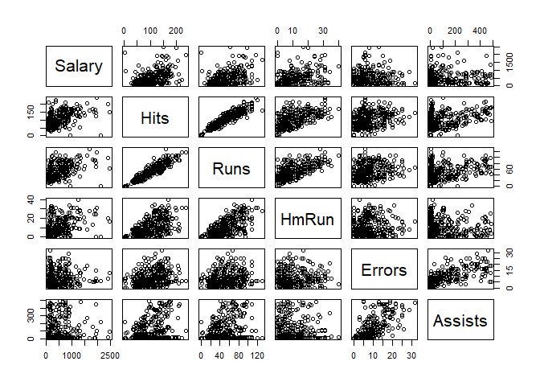

```r
pairs(Hitters[,c("Salary", "Hits", "Runs", "HmRun", "Errors", "Assists")])
```

The stronges and most obvious linear relationship is between Hits and Runs. However there seems to be relationships between Runs and HmRun as well as Hits and HmRun. These relationships seem quite obvious at face value.

### 6g (2 points)

SKIP

### 6h (2 points)

Create a new variable called HighRBI for those players with at least 75 RBI (TRUE). Players with less than 75 RBI should have the value FALSE.

```r
Hitters$HighRBI<- Hitters$RBI>=75
```

### 6i (2 points)

What percentage of hitters qualified as HighRBI during these seasons?

```r
percent(mean(Hitters$HighRBI))
```

```
[1] "18.6%"
```

### 6j (2 points)

What is the correlation of HighRBI, Home Runs, Hits, Runs, Assists, and Errors with Salary? Use only the cases in which both variables are measured. Round the answer to two decimal places.

```r
#calculate correlations and but remove NA values
cors<- Hitters%>%
  select(HighRBI, HmRun, Hits, Runs, Assists, Errors, Salary)%>%
  na.omit()%>%
  cor()

#correlations with Salary
cors[1:6,"Salary"]
```

```
     HighRBI        HmRun         Hits         Runs      Assists
 0.365297725  0.343028078  0.438674738  0.419858559  0.025436136
      Errors
-0.005400702
```

### 6k (2 points)

How did the salaries differ for players with and without HighRBI? Use the **boxplot** function and **?split** the salary data by HighRBI status. Do HighRBI players have a higher median salary?

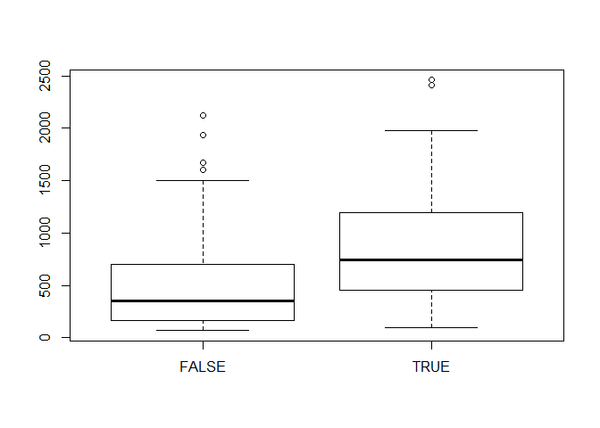

```r
#split salary by the two groups of high and low RBI's
split_HighRBI <- split(Hitters$Salary, Hitters$HighRBI)

#plot distributions using boxplot
boxplot(split_HighRBI)
```

```r
#calculate the difference between the two groups salary
split_HighRBI%>%
  lapply(mean, na.rm = T)%>%
  unlist()%>%
  diff()
```

```
    TRUE
401.7789
```

From this image HighRBI players have a higher median salary. In fact it is almost double.

```r
t.test(unlist(split_HighRBI[1]),unlist(split_HighRBI[2]))
```

```
    Welch Two Sample t-test

data:  unlist(split_HighRBI[1]) and unlist(split_HighRBI[2])
t = -4.8764, df = 66.84, p-value = 6.989e-06
alternative hypothesis: true difference in means is not equal to 0
95 percent confidence interval:
 -566.2407 -237.3171
sample estimates:
mean of x mean of y
 450.3760  852.1549
```

### 6l (2 points)

Show a histogram of home runs using the **hist** function with **breaks = 20** and **freq = FALSE**.

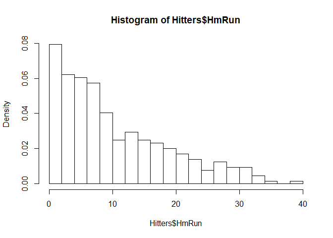

```r
hist(Hitters$HmRun, breaks = 20, freq = FALSE)
```

## Question 7 (10 points)

### 7a (2 points)

What is the mean and standard deviation of Hits, Runs, Home Runs, RBI, Assists, Errors, and Salaries? Remove any missing values from the calculations. Round the answers to 1 decimal place.

```r
#create summary data frame
Hitters_sumstats_2<- Hitters%>%
  select(Hits, HmRun, Runs, RBI, Assists, Errors, Salary)%>%
  na.omit()%>%
  summarize_all(funs(mean,sd))%>%
  round(1)

#reorder df
Hitters_sumstats_2<- Hitters_sumstats_2[,sort(names(Hitters_sumstats_2))]

Hitters_sumstats_2
```

```
  Assists_mean Assists_sd Errors_mean Errors_sd Hits_mean Hits_sd
1        118.8      145.1         8.6       6.6     107.8    45.1
  HmRun_mean HmRun_sd RBI_mean RBI_sd Runs_mean Runs_sd Salary_mean
1       11.6      8.8     51.5   25.9      54.7    25.5       535.9
  Salary_sd
1     451.1
```

### 7b (2 points)

Some players only get to play part-time. Show the mean and standard deviations for the same variables as in the previous question **only for players with at least 300 AtBat**.

```r
#create summary df
Hitters_sumstats_3<- Hitters%>%
  filter(AtBat>=300)%>%
  select(Hits, HmRun, Runs, RBI, Assists, Errors, Salary)%>%
  na.omit()%>%
  summarize_all(funs(mean,sd))%>%
  round(1)

#reorder df
Hitters_sumstats_3<- Hitters_sumstats_3[,sort(names(Hitters_sumstats_3))]

Hitters_sumstats_3
```

```
  Assists_mean Assists_sd Errors_mean Errors_sd Hits_mean Hits_sd
1        143.5      158.9         9.9       6.9     128.3    35.2
  HmRun_mean HmRun_sd RBI_mean RBI_sd Runs_mean Runs_sd Salary_mean
1         14        9     61.4   23.2      65.5    21.5       617.1
  Salary_sd
1     467.7
```

### 7c (2 points)

Show a scatter plot of Salary versus Home Runs for players with at least 300 AtBat.

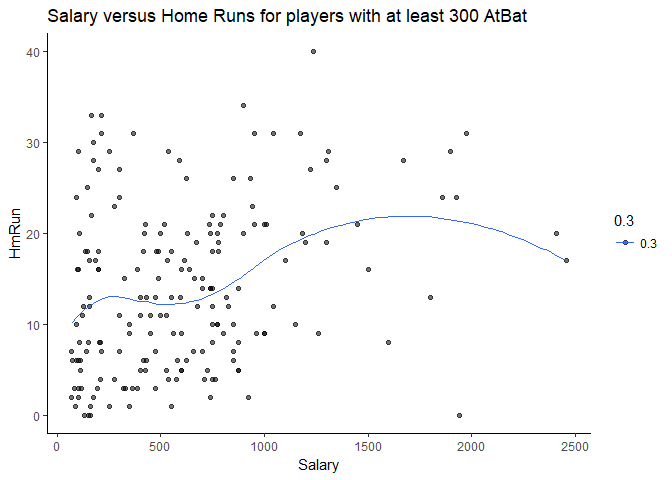

```r
#create subset of main df
Hitters_AtBat_300 <- Hitters%>%
  filter(AtBat>=300)%>%
  na.omit()

#plot the subsetted data
ggplot(Hitters_AtBat_300, aes(x=Salary, y= HmRun, alpha =.3))+
  mytheme+
  geom_point()+
  geom_smooth(method = 'loess',se = F,  lwd = .5) +
  labs(title = 'Salary versus Home Runs for players with at least 300 AtBat')
```

### 7d (2 points)

There is a player with zero home runs and a salary over 2,000 (more than 2 million dollars). Who is this player? What does it look like happened during the season? Are these numbers accurate? Use the internet to search for this player’s results in 1986 and 1987.

```r
Hitters[which(Hitters$HmRun == 0 & Hitters$Salary > 2000),]
```

```
              AtBat Hits HmRun Runs RBI Walks Years CAtBat CHits CHmRun
-Mike Schmidt    20    1     0    0   0     0     2     41     9      2
              CRuns CRBI CWalks League Division PutOuts Assists Errors
-Mike Schmidt     6    7      4      N        E      78     220      6
                Salary NewLeague HighRBI
-Mike Schmidt 2127.333         N   FALSE
```

The player is Mike Schmidt.

### 7e (2 points)

Continue exploring the data set. Briefly report (2-3 sentences) on what else you found.

```r
#look at corrolations of all variables

#find all numeric variables
col_str<-c()
for(i in 1:ncol(Hitters)){
  col_str[i]<-is.numeric(Hitters[,i])
}

#calculate correlations
corr_Hitters<- cor(na.omit(Hitters[,col_str]))
```

```
#set color palette
col <- colorRampPalette(c("#BB4444", "#EE9988", "#FFFFFF", "#77AADD", "#4477AA"))
#plot correlation matrix
corrplot(corr_Hitters, method="color", col=col(200),
         type="upper", order="hclust",
         addCoef.col = "black", # Add coefficient of correlation
         tl.col="black", tl.srt=45, #Text label color and rotation
         # Combine with significance
         sig.level = 0.01, insig = "blank",
         # hide correlation coefficient on the principal diagonal
         diag=FALSE
         )
```

[figure not shown]

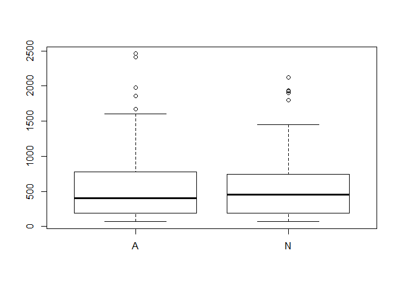

```r
#Look at Salary differences by League
split_league <- split(Hitters$Salary, Hitters$League)
#plot distributions using boxplot
boxplot(split_league)
```

```r
#find the differnece between leagues average salary
split_league%>%
  lapply(mean, na.rm = T)%>%
  unlist()%>%
  diff()
```

```
        N
-12.88205
```

```r
#perform hypothese testing to determin if the difference is statistically significant
t.test(unlist(split_league[1]),unlist(split_league[2]))
```

```
    Welch Two Sample t-test

data:  unlist(split_league[1]) and unlist(split_league[2])
t = 0.23157, df = 260.26, p-value = 0.8171
alternative hypothesis: true difference in means is not equal to 0
95 percent confidence interval:
 -96.66039 122.42448
sample estimates:
mean of x mean of y
 541.9995  529.1175
```

I found it intersting that there was a high positive corrolation between Assits and Errors. The difference in average salary between leagues was higher than I expected being about $12,000. But the result of a hypothesis test shows a p.value of 0.8171 giving no evidence that there is a real difference between Salary distributions of the Leagues.